# Multimodal single-cell RNA-seq analysis

Anna Szymik

2023-06-11

## Data exploration

```r
# Load the data as matrices, as they will be used by the functions we will use
y_train <- read.delim('y_train.csv', sep=',', dec='.')
y <- y_train$Expected
X_train <- as.matrix(read.delim('X_train.csv', sep=',', dec='.'))
X_test <- as.matrix(read.delim('X_test.csv', sep=',', dec='.'))
```

```r
# Check the type of values in columns
unlist(lapply(X_test, class))
str(y_train)
str(X_test)
```

```r
# Check if there are any missing values
colSums(is.na(X_train))
colSums(is.na(X_test))
colSums(is.na(y_train))
```

```r
# Check data dimensions
dim(X_train)
```

```
## [1] 3794 9000
```

```r
dim(y_train)
```

```
## [1] 3794    2
```

```r
dim(X_test)
```

```
## [1]  670 9000
```

The training data contains observations from 3794 cells, concerning the expression of 9000 genes – this is a typical case for RNA-Seq analysis with $p > n$, where special caution is needed to avoid overfitting. The test data contains 670 expression values of the same 9000 genes. The data is complete, and the columns are numeric, so no conversion is needed.

### Empirical distribution of the explained variable

Let’s start by calculating basic statistics, such as the mean, median, and standard deviation from the sample.

```r
mean(y_train$Expected)
```

```
## [1] 1.495855
```

```r
median(y_train$Expected)
```

```
## [1] 0.9383942
```

```r
sd(y_train$Expected)
```

```
## [1] 1.49909
```

Now let’s present the data on the charts.

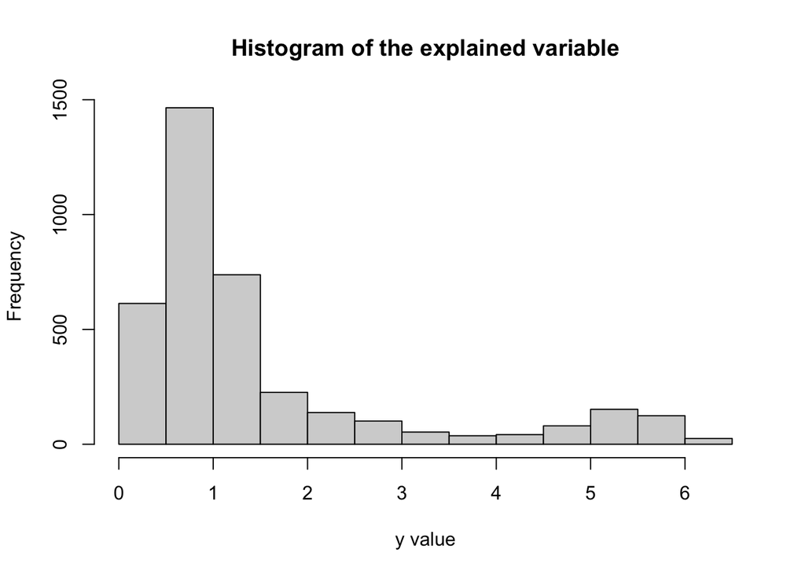

```r
hist(y_train$Expected, breaks = "Sturges", main = "Histogram of the explained variable", xlab = "y value")
```

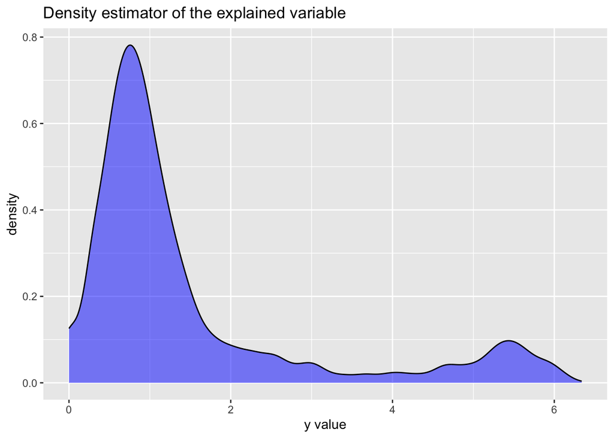

```r
ggplot(data = data.frame(y_train$Expected), aes(x = y_train$Expected)) +
  geom_density(fill = "blue", alpha = 0.5) +
  labs(title = "Density estimator of the explained variable", x = "y value", y = "density")
```

The distribution of the explained variable is bimodal, with the majority of values concentrated around one and the second significant part concentrated around five.

### Correlation heatmap

Correlation heatmap of the 250 explanatory variables most correlated with the explained variable.

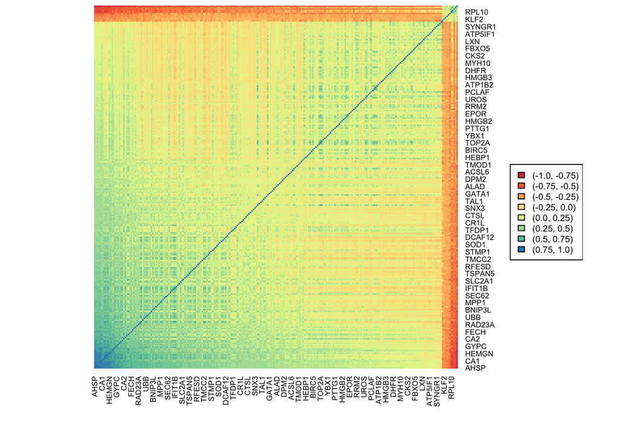

```r
# Znajdujemy zmienne najbardziej skorelowane z y
cor_matrix <- cor(X_train, y_train$Expected)
top <- order(abs(cor_matrix[,1]), decreasing=TRUE)[1:250]
selected_vars <- X_train[, top]

# Change the order to make the heatmap more readable
selected_order <- cor(selected_vars, selected_vars[,1])
selected_order <- selected_order[order(selected_order, decreasing = TRUE),]
selected_order <- names(selected_order)
cor_selected <- cor(X_train[,selected_order])

# Create a heatmap
heatmap(cor_selected,
        Rowv = NA,
        Colv = NA,
        scale = "none",
        col = colorRampPalette(brewer.pal(8, "Spectral"))(25))

legend(x="right",
       legend=c("(-1.0, -0.75)", "(-0.75, -0.5)", "(-0.5, -0.25)", "(-0.25, 0.0)", "(0.0, 0.25)","(0.25, 0.5)", "(0.5, 0.75)", "(0.75, 1.0)"),
       fill=colorRampPalette(brewer.pal(8, "Spectral"))(8), cex = 0.6)
```

## ElasticNet

### Method description

The ElasticNet model is a combination of Ridge Regression and Lasso Regression. It is used to solve regression problems, especially in cases where the dataset contains many explanatory variables that may be correlated with each other. ElasticNet estimates the regression coefficients for each explanatory variable by minimizing the cost function of the following form:

$$L(\beta) = \text{RSS}(\beta) + \lambda \sum_{j=1}^{p}(\alpha |\beta_j| +
\frac{1-\alpha}{2}\beta_j^2)$$

The cost function is a combination of two components:

- linear L1 norm – as in Lasso Regression – promoting sparsity in the resulting coefficients, meaning that many of them can be exactly equal to zero, thus leading to variable selection;
- quadratic L2 norm – as in Ridge Regression – reducing the values of the coefficients, but not causing them to be exactly zeroed.

Hyperparameters of the method:

- $\alpha$ – the mixing coefficient between Lasso Regression and Ridge Regression. $\alpha$ controls the balance between variable selection (Lasso Regression) and coefficient reduction (Ridge Regression). For a value of 0, we are dealing with pure Ridge Regression, and for 1 – with pure Lasso Regression.
- $\lambda$ – the regularization parameter, controlling how strongly parameters are pulled to 0. The larger the value of $\lambda$, the stronger the regularization and the smaller the value of the regression coefficients.

### Hyperparameter grid

Let’s define the following hyperparameter grid for the method:

```r
alphas <- seq(0, 1, by=0.1)
lambdas <- seq(1, 0, by=-0.1)
```

Let’s perform $k$-fold cross-validation to select the parameter combination that gives the smallest validation error. Let’s assume $k=5$, one of the two most commonly used values, which gives satisfactory results while not consuming as much computing power as cross-validation with $k=10$.

```r
k <- 5  # number of folds
set.seed(3)  # random seed for result reproducibility
folds <- createFolds(y, k)
```

```r
parallelStartSocket(cpus=detectCores())

# Matrices to store training and validation errors
en_train_errors <- matrix(NA, nrow = length(alphas), ncol = length(lambdas))
en_valid_errors <- matrix(NA, nrow = length(alphas), ncol = length(lambdas))

# 5-fold cross-validation for each parameter combination
for (i in 1:length(alphas)) {
    train_errors <- c(1:length(lambdas))
    valid_errors <- c(1:length(lambdas))

    for (fold in 1:k) {
      train_index <- unlist(folds[-fold])  # indices of the training subset
      valid_index <- folds[[fold]]  # indices of the validation subset

      x_train_fold <- X_train[train_index, ]
      y_train_fold <- y[train_index]
      x_valid_fold <- X_train[valid_index, ]
      y_valid_fold <- y[valid_index]

      model <- glmnet(x_train_fold, y_train_fold, alpha = alphas[i], lambda = lambdas)
      pred <- predict(model, X_train, s = lambdas)

      train_pred <- pred[train_index,]  # predictions for the training set
      valid_pred <- pred[valid_index,]  # predictions for the validation set

      for (j in 1:length(lambdas)) {
        # Training RMSE for each lambda
        train_errors[j] <- sqrt(mean((train_pred[j] - y_train_fold)^2))
        # Validation RMSE
        valid_errors[j] <- sqrt(mean((valid_pred[j] - y_valid_fold)^2))
      }
    }
    en_train_errors[i,] <- train_errors
    en_valid_errors[i,] <- valid_errors
}

# Naming columns with appropriate values
colnames(en_train_errors) <- lambdas
colnames(en_valid_errors) <- lambdas
rownames(en_train_errors) <- alphas
rownames(en_valid_errors) <- alphas

write.table(en_train_errors, file = "en_train_errors.csv")
write.table(en_valid_errors, file = "en_valid_errors.csv")
parallelStop()
```

```r
# Select alpha and lambda with the smallest validation error
indices <- which(en_valid_errors == min(en_valid_errors), arr.ind=TRUE)
alphas[indices[1]]
```

```
## [1] 0.8
```

```r
lambdas[indices[2]]
```

```
## [1] 0.2
```

```r
# Mean validation error for selected parameters
en_valid_err <- en_valid_errors[indices]
en_train_err <- en_train_errors[indices]
```

```r
en_valid_err
```

```
## [1] 1.494144
```

```r
en_train_err
```

```
## [1] 1.503874
```

## Random Forests

Hyperparameters to be tested:

- `mtry` – the number of predictors randomly sampled for constructing a tree – for regression problems, usually $m=\frac{p}{3}$ is used, so this will be one of the parameters considered
- `max.depth` – the maximum depth of the tree
- `min.node.size` – the minimum number of observations in a leaf

```r
parallelStartSocket(cpus=detectCores())
p <- ncol(X_train)
n <- nrow(X_train)

# Create a hyperparameter grid
rf_hyper_grid <- expand.grid(
  mtry = floor(p * c(.01, .1, .333)),
  min.node.size = c(5,10,20),
  max.depth = c(10, 20, 50, NULL),
  train_rmse = NA,
  valid_rmse = NA
)

# Perform 5-fold cross-validation for each parameter combination
for(i in seq_len(nrow(rf_hyper_grid))) {
  train_errors <- c(1:k)
  valid_errors <- c(1:k)

  for (fold in 1:k) {

      train_index <- unlist(folds[-fold])
      valid_index <- folds[[fold]]

      x_train_fold <- X_train[train_index, ]
      y_train_fold <- y[train_index]
      x_valid_fold <- X_train[valid_index, ]
      y_valid_fold <- y[valid_index]

      model <- ranger(
          x               = x_train_fold,
          y               = y_train_fold,
          num.trees       = 50,
          mtry            = rf_hyper_grid$mtry[i],
          min.node.size   = rf_hyper_grid$min.node.size[i],
          verbose         = FALSE,
          seed            = 7,
          max.depth       = rf_hyper_grid$max.depth[i]
      )

      # Predictions for the validation set
      valid_pred <- predict(model, x_valid_fold)$predictions

      # Training RMSE
      train_errors[fold] <- sqrt(model$prediction.error)

      # Validation RMSE
      valid_errors[fold] <- sqrt(mean((valid_pred - y_valid_fold)^2))
  }

  # Mean RMSE values
  rf_hyper_grid$train_rmse[i] <- mean(train_errors)
  rf_hyper_grid$valid_rmse[i] <- mean(valid_errors)

}
write.table(rf_hyper_grid, file = "rf_hyper_grid.csv")
parallelStop()
```

```r
# Choose parameters with smallest validation error
index <- which.min(rf_hyper_grid$valid_rmse)

rf_hyper_grid[index,]
```

```
##    mtry min.node.size max.depth train_rmse valid_rmse
## 18 2997            20        20  0.4759874  0.4676071
```

```r
rf_best_params <- rf_hyper_grid[index,1:3]

rf_valid_err <- rf_hyper_grid$valid_rmse[index]
rf_train_err <- rf_hyper_grid$train_rmse[index]
```

## Model comparison

```r
# Reference Model
mean_y <- mean(y)

train_errors <- c(1:k)
valid_errors <- c(1:k)

for (fold in 1:k) {

  train_index <- unlist(folds[-fold])
  valid_index <- folds[[fold]]

  x_train_fold <- X_train[train_index, ]
  y_train_fold <- y[train_index]
  x_valid_fold <- X_train[valid_index, ]
  y_valid_fold <- y[valid_index]

  train_errors[fold] <- sqrt(mean((mean_y - y_train_fold)^2))
  valid_errors[fold] <- sqrt(mean((mean_y - y_valid_fold)^2))

}

index <- which.min(valid_errors)
ref_valid_err <- valid_errors[index]
ref_train_err <- train_errors[index]

summary <- matrix(c(en_train_err, en_valid_err, rf_train_err, rf_valid_err, ref_train_err, ref_valid_err), nrow=2)
colnames(summary) <- c("ElasticNet", "RandomForest", "Reference")
rownames(summary) <- c("training", "validation")
summary
```

```
##            ElasticNet RandomForest Reference
## training     1.503874    0.4759874  1.507751
## validation   1.494144    0.4676071  1.462991
```

Comparing the test and validation errors, it’s not hard to see that the models based on random forests were able to fit the data much better. Such results are not surprising - random forests, using a random subset of predictors and observations each time, reduce the variance of the model. Thanks to this, they are much less prone to overfitting, the biggest threat in the case of the analyzed data. Additionally, they are able to model nonlinear dependencies between explanatory variables and the explained variable. Thus, of the models presented above, it is the random forests that are much more suitable for prediction.

## Prediction on the test set

### XGBoost

The model used for prediction will be XGBoost, which creates strong models by combining information from many weak predictive models. It uses decision trees created sequentially, where each subsequent tree is adapted to correct the errors made by previous trees. XGBoost has built-in regularization mechanisms that help control the complexity of the model and prevent overfitting. You can adjust parameters such as tree depth, weight coefficients in the loss function, sampling of training data, etc. It has many hyperparameters, which I will optimize separately.

```r
# PCA - ultimately unused, because predictions without it gave a smaller error
pca <- prcomp(X_train)
var <- cumsum(pca$sdev^2)/sum(pca$sdev^2)
ggplot() + geom_line(aes(x=c(1:n), y=var))
end <- length(var[var<0.95])+1 # at which index do we have > 95% variance explained
new_X <- pca$x[,1:end]
```

```r
parallelStartSocket(cpus=detectCores())

# Create an initial list of parameters
param_list = list(
objective = "reg:linear",
eta = 0.01,
gamma = 1,
max_depth = 6,
subsample = 0.8,
colsample_bytree = 0.5
)

# Convert the data to the xgb.DMatrix format
xgb_train <- xgb.DMatrix(data = new_X, label = y)

# Multiply the test data by the principal directions
new_X_test <- X_test %*% pca$rotation[,1:end]
xgb_test = xgb.DMatrix(data = new_X_test)

parallelStop()
```

### Hyperparameter tuning

```r
xtrain = X_train[train,]
ytrain = y[train]
xtest = X_train[test,]
ytest = y[test]

# Hyperparameter grid
eta <- c(0.01, 0.3)
cs <- c(1/3,2/3,1)
md <- c(4,6,10)
ss <- c(0.25,0.5,0.75,1)
mcw <- c(1,10,100,400)
gamma <- c(0.1,1,10,100)

# Positions of standard values of parameters eta, cs, md, ss, mcw, gamma
standard <- c(2, 3, 2, 1, 1, 1)

parallelStartSocket(cpus=detectCores())

# Search for the best eta
set.seed(1)
conv_eta = matrix(NA, 500,length(eta))
pred_eta = matrix(NA,length(test), length(eta))
colnames(conv_eta) = colnames(pred_eta) = eta
for(i in 1:length(eta)){
  params=list(eta = eta[i], colsample_bylevel=cs[standard[2]],
              subsample = ss[standard[4]], max_depth = md[standard[3]],
              min_child_weigth = 1)
  xgb = xgboost(xtrain, label = ytrain, nrounds = 500, params = params)
  conv_eta[,i] = xgb$evaluation_log$train_rmse
  pred_eta[,i] = predict(xgb, xtest)
}
conv_eta = data.frame(iter=1:500, conv_eta)
conv_eta = melt(conv_eta, id.vars = "iter")
```

[figure not shown]

```r
ggplot(data = conv_eta) + geom_line(aes(x = iter, y = value, color = variable))
```

```r
RMSE_eta = sqrt(colMeans((ytest-pred_eta)^2))
best_eta <- as.numeric(names(which.min(RMSE_eta)))

write.table(conv_eta, file = "conv_eta.csv")
write.table(pred_eta, file = "pred_eta.csv")

parallelStartSocket(cpus=detectCores())
# Test the fraction of variables tested at each new node
set.seed(1)
conv_cs = matrix(NA, 500, length(cs))
pred_cs = matrix(NA,length(test), length(cs))
colnames(conv_cs) = colnames(pred_cs) = cs
for(i in 1:length(cs)){
  params = list(eta = eta[standard[1]], colsample_bylevel = cs[i],
                subsample = ss[standard[4]], max_depth = md[standard[3]],
                min_child_weigth = 1)
  xgb=xgboost(xtrain, label = ytrain, nrounds = 500, params = params)
  conv_cs[,i] = xgb$evaluation_log$train_rmse
  pred_cs[,i] = predict(xgb, xtest)
}
conv_cs = data.frame(iter=1:500, conv_cs)
conv_cs = melt(conv_cs, id.vars = "iter")
```

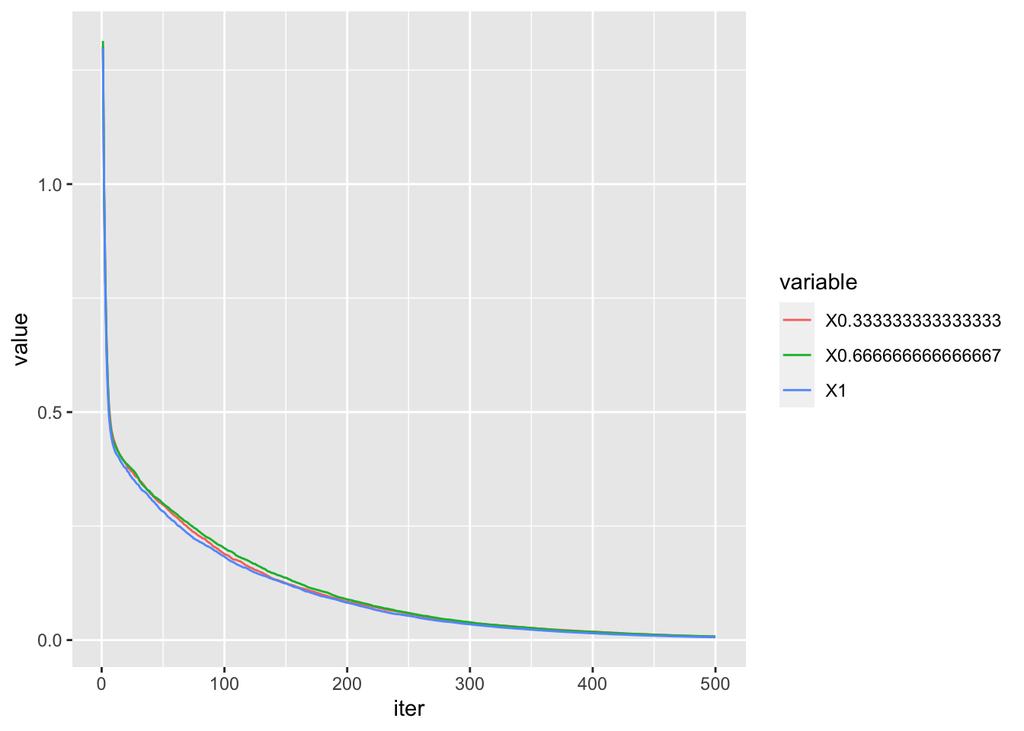

```r
ggplot(data = conv_cs) + geom_line(aes(x = iter, y = value, color = variable))
```

```r
RMSE_cs = sqrt(colMeans((ytest-pred_cs)^2))
best_cs <- as.numeric(names(which.min(RMSE_cs)))

write.table(conv_cs, file = "conv_cs.csv")
write.table(pred_cs, file = "pred_cs.csv")

# Search for the best tree depth
set.seed(1)
conv_md <- matrix(NA,500,length(md))
pred_md <- matrix(NA,length(test), length(md))
colnames(conv_md) = colnames(pred_md) = md
for(i in 1:length(md)){
  params = list(eta = eta[standard[1]], colsample_bylevel = cs[standard[2]],
                subsample = ss[standard[4]], max_depth = md[i],
                min_child_weigth = 1)
  xgb=xgboost(xtrain, label = ytrain, nrounds = 500, params = params)
  conv_md[,i] = xgb$evaluation_log$train_rmse
  pred_md[,i] = predict(xgb, xtest)
}
conv_md <- data.frame(iter=1:500, conv_md)
conv_md <- melt(conv_md, id.vars = "iter")
ggplot(data = conv_md) + geom_line(aes(x = iter, y = value, color = variable))

RMSE_md <- sqrt(colMeans((ytest-pred_md)^2))
best_md <- as.numeric(names(which.min(RMSE_md)))

write.table(conv_md, file = "conv_md.csv")
write.table(pred_md, file = "pred_md.csv")

# Search for the best subsample value
set.seed(1)
conv_ss=matrix(NA,500,length(ss))
pred_ss=matrix(NA,length(test),length(ss))
colnames(conv_ss)=colnames(pred_ss)=ss
for(i in 1:length(ss)){
  params=list(eta=eta[standard[1]],colsample_bylevel=cs[standard[2]],
              subsample=ss[i],max_depth=md[standard[3]],
              min_child_weigth=1)
  xgb=xgboost(xtrain, label = ytrain,nrounds = 500,params=params)
  conv_ss[,i] = xgb$evaluation_log$train_rmse
  pred_ss[,i] = predict(xgb, xtest)
}
conv_ss=data.frame(iter=1:500,conv_ss)
conv_ss=melt(conv_ss,id.vars = "iter")
```

[output not shown]

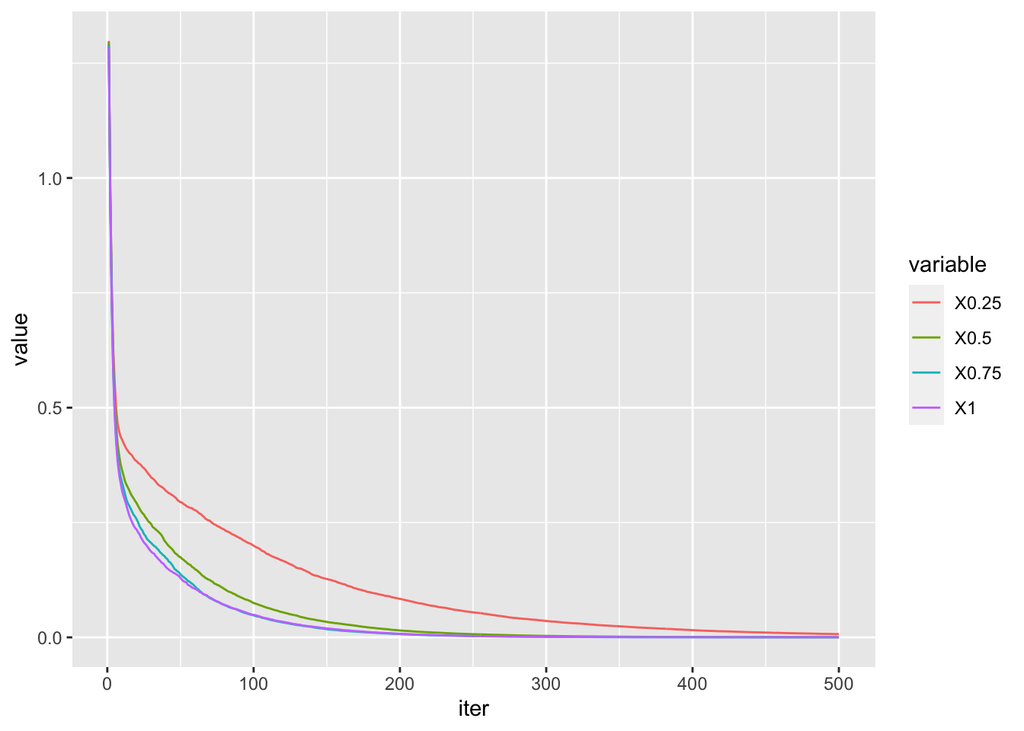

```r
ggplot(data=conv_ss)+geom_line(aes(x=iter,y=value,color=variable))
```

```r
RMSE_ss <- sqrt(colMeans((ytest-pred_ss)^2))
best_ss <- as.numeric(names(which.min(RMSE_ss)))

write.table(conv_ss, file = "conv_ss.csv")
write.table(pred_ss, file = "pred_ss.csv")

# Search for the best min_child_weight value
set.seed(1)
conv_mcw = matrix(NA,500,length(mcw))
pred_mcw = matrix(NA,length(test), length(mcw))
colnames(conv_mcw) = colnames(pred_mcw) = mcw
for(i in 1:length(mcw)){
  params = list(eta = 0.1, colsample_bylevel=2/3,
                subsample = 1, max_depth = 6,
                min_child_weight = mcw[i], gamma = 0)
  xgb = xgboost(xtrain, label = ytrain, nrounds = 500, params = params)
  conv_mcw[,i] = xgb$evaluation_log$train_rmse
  pred_mcw[,i] = predict(xgb, xtest)
}
conv_mcw = data.frame(iter=1:500, conv_mcw)
conv_mcw = melt(conv_mcw, id.vars = "iter")
```

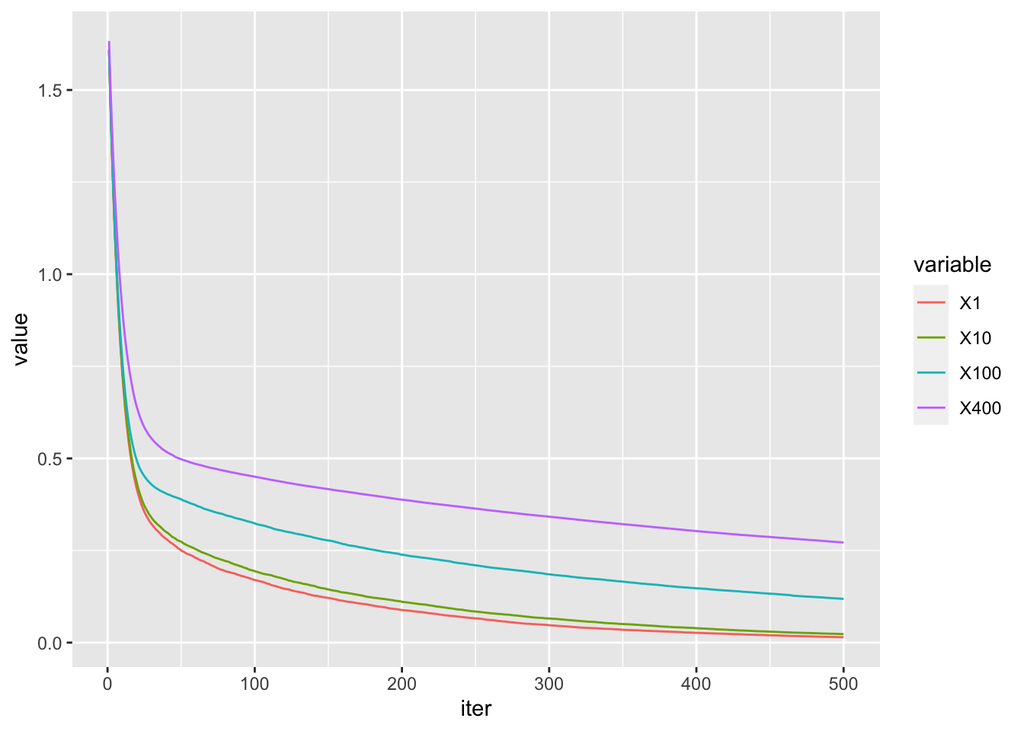

```r
ggplot(data = conv_mcw) + geom_line(aes(x = iter, y = value, color = variable))
```

```r
RMSE_mcw <- sqrt(colMeans((ytest-pred_mcw)^2))
best_mcw <- as.numeric(names(which.min(RMSE_mcw)))

write.table(conv_mcw, file = "conv_mcw.csv")
write.table(pred_mcw, file = "pred_mcw.csv")

# Search for the best gamma value
set.seed(1)
conv_gamma = matrix(NA,500,length(gamma))
pred_gamma = matrix(NA,length(test), length(gamma))
colnames(conv_gamma) = colnames(pred_gamma) = gamma
for(i in 1:length(gamma)){
  params = list(eta = 0.1, colsample_bylevel=2/3,
                subsample = 1, max_depth = 6, min_child_weight = 1,
                gamma = gamma[i])
  xgb = xgboost(xtrain, label = ytrain, nrounds = 500, params = params)
  conv_gamma[,i] = xgb$evaluation_log$train_rmse
  pred_gamma[,i] = predict(xgb, xtest)
}
conv_gamma = data.frame(iter=1:500, conv_gamma)
conv_gamma = melt(conv_gamma, id.vars = "iter")
```

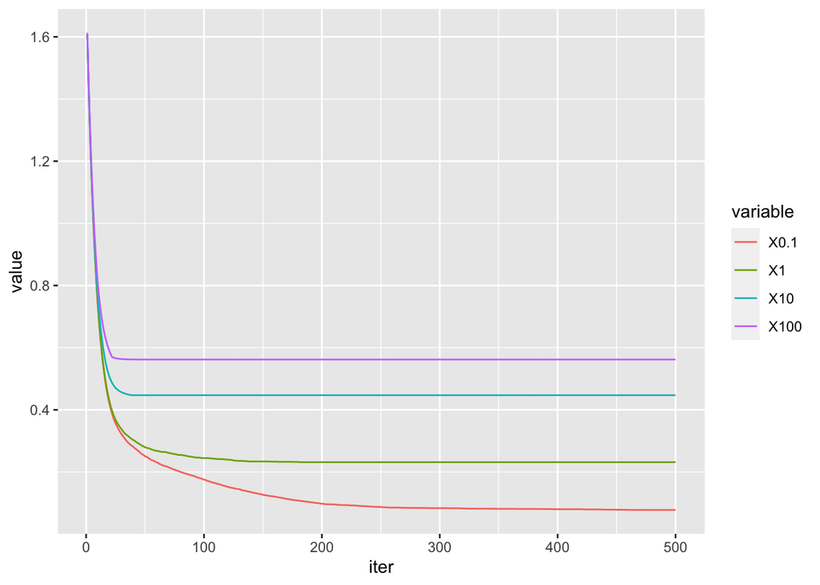

```r
ggplot(data = conv_gamma) + geom_line(aes(x = iter, y = value, color = variable))
```

```r
RMSE_gamma <- sqrt(colMeans((ytest-pred_gamma)^2))
best_gamma <- as.numeric(names(which.min(RMSE_gamma)))

write.table(conv_gamma, file = "conv_gamma.csv")
write.table(pred_gamma, file = "pred_gamma.csv")

# Create an initial list of parameters
param_list <- list(
  objective = "reg:squarederror",
  eta = best_eta,
  gamma = best_gamma,
  max_depth = best_md,
  subsample = best_ss,
  colsample_bylevel = best_cs,
  min_child_weight = best_mcw)

# Convert the data to the xgb.DMatrix format
xgb_train <- xgb.DMatrix(data = X_train, label = y)
xgb_test <- xgb.DMatrix(data = X_test)

# 5-fold cross-validation to find the optimal number of algorithm runs
set.seed(113)
xgbcv2 <- xgb.cv(params = param_list,
                data = xgb_train,
                nrounds = 1000,
                nfold = 5,
                print_every_n = 10,
                early_stopping_rounds = 30,
                maximize = F)

best_iter <- xgbcv2$best_iteration

# Train XGBoost model with the found number of runs
xgb_model2 = xgb.train(data = xgb_train,
                      params = param_list,
                      nrounds = best_iter,
                      eval_metric = "error")
xgb_model2

predictions <- predict(object = xgb_model2, newdata = xgb_test)
pred_table <- as.data.frame(c(0:669))
colnames(pred_table) <- "Id"
pred_table$Expected <- predictions
write.table(pred_table, sep = ',', file = "pred_table.csv", row.names = FALSE)

parallelStop()
```